# IE 451 Homework 7

Author

Mustafa Mert Türkmen

## 8

### 8.a

```r
set.seed(1907)
x <- rnorm(100)
ep <- rnorm(100)
```

### 8.b

```r
y <- 24 + 3*x + 1*x^2 + 5*x^3 + ep
```

### 8.c

```r
df <- data.frame(x,y)
reg <- regsubsets(y~poly(x,10,raw = TRUE, simple = TRUE), nvmax = 10, data = df)
summary(reg)
```

```
Subset selection object
Call: regsubsets.formula(y ~ poly(x, 10, raw = TRUE, simple = TRUE),
    nvmax = 10, data = df)
10 Variables  (and intercept)
                                         Forced in Forced out
poly(x, 10, raw = TRUE, simple = TRUE)1      FALSE      FALSE
poly(x, 10, raw = TRUE, simple = TRUE)2      FALSE      FALSE
poly(x, 10, raw = TRUE, simple = TRUE)3      FALSE      FALSE
poly(x, 10, raw = TRUE, simple = TRUE)4      FALSE      FALSE
poly(x, 10, raw = TRUE, simple = TRUE)5      FALSE      FALSE
poly(x, 10, raw = TRUE, simple = TRUE)6      FALSE      FALSE
poly(x, 10, raw = TRUE, simple = TRUE)7      FALSE      FALSE
poly(x, 10, raw = TRUE, simple = TRUE)8      FALSE      FALSE
poly(x, 10, raw = TRUE, simple = TRUE)9      FALSE      FALSE
poly(x, 10, raw = TRUE, simple = TRUE)10     FALSE      FALSE
```

[output cut: 112 more lines]

```r
cp_values <- summary(reg)$cp
bic_values <- summary(reg)$bic
adjr2_values <- summary(reg)$adjr2
```

```r
min_cp_index <- which.min(cp_values)
min_bic_index <- which.min(bic_values)
max_adjr2_index <- which.max(adjr2_values)
```

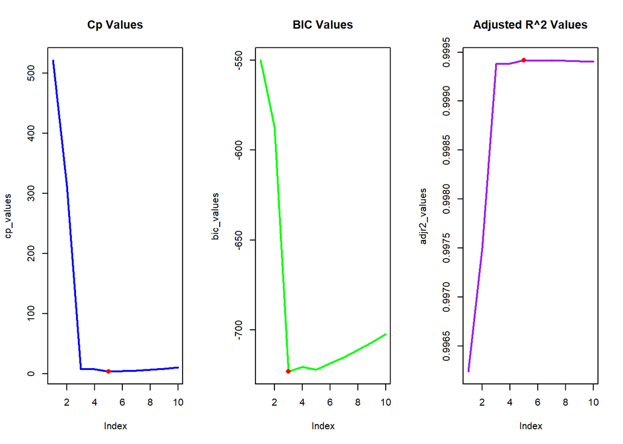

```r
par(mfrow = c(1, 3))
plot(cp_values, main = "Cp Values", type = "l", col = "blue", lwd = 2)
points(min_cp_index, cp_values[min_cp_index], col = "red", pch = 16)

plot(bic_values, main = "BIC Values", type = "l", col = "green", lwd = 2)
points(min_bic_index, bic_values[min_bic_index], col = "red", pch = 16)

plot(adjr2_values, main = "Adjusted R^2 Values", type = "l", col = "purple", lwd = 2)
points(max_adjr2_index, adjr2_values[max_adjr2_index], col = "red", pch = 16)
```

- With looking minimum Cp value and maximum AdjR2 values we can create a model with five variable.

```r
bic_values
```

```
 [1] -550.1084 -587.3166 -723.1050 -720.4382 -722.1010 -718.4023 -715.0289
 [8] -710.8428 -706.8920 -702.2883
```

- There is not much difference in bic_values at using 3 or 5 variable, so we can create best model with five variable according to these three parameters.

```r
coef(reg, id = 3)
```

```
                            (Intercept) poly(x, 10, raw = TRUE, simple = TRUE)1
                              24.048086                                3.128622
poly(x, 10, raw = TRUE, simple = TRUE)2 poly(x, 10, raw = TRUE, simple = TRUE)3
                               1.022358                                4.971037
```

- The coefficients as we would expect.
- Intercept is close to 24.05 which is very close the 24.
- The model has contained X^1, X^2 and X^3, the values are close to our coefficients.

### 8.d

```r
reg_forward <- regsubsets(y~poly(x,10,raw = TRUE, simple = TRUE), nvmax = 10, data = df, method='forward')
summary(reg_forward)
```

```
Subset selection object
Call: regsubsets.formula(y ~ poly(x, 10, raw = TRUE, simple = TRUE),
    nvmax = 10, data = df, method = "forward")
10 Variables  (and intercept)
                                         Forced in Forced out
poly(x, 10, raw = TRUE, simple = TRUE)1      FALSE      FALSE
poly(x, 10, raw = TRUE, simple = TRUE)2      FALSE      FALSE
poly(x, 10, raw = TRUE, simple = TRUE)3      FALSE      FALSE
poly(x, 10, raw = TRUE, simple = TRUE)4      FALSE      FALSE
poly(x, 10, raw = TRUE, simple = TRUE)5      FALSE      FALSE
poly(x, 10, raw = TRUE, simple = TRUE)6      FALSE      FALSE
poly(x, 10, raw = TRUE, simple = TRUE)7      FALSE      FALSE
poly(x, 10, raw = TRUE, simple = TRUE)8      FALSE      FALSE
poly(x, 10, raw = TRUE, simple = TRUE)9      FALSE      FALSE
poly(x, 10, raw = TRUE, simple = TRUE)10     FALSE      FALSE
```

[output cut: 112 more lines]

```r
cp_values_f <- summary(reg_forward)$cp
bic_values_f <- summary(reg_forward)$bic
adjr2_values_f <- summary(reg_forward)$adjr2
```

```r
min_cp_index_f <- which.min(cp_values_f)
min_bic_index_f <- which.min(bic_values_f)
max_adjr2_index_f <- which.max(adjr2_values_f)
```

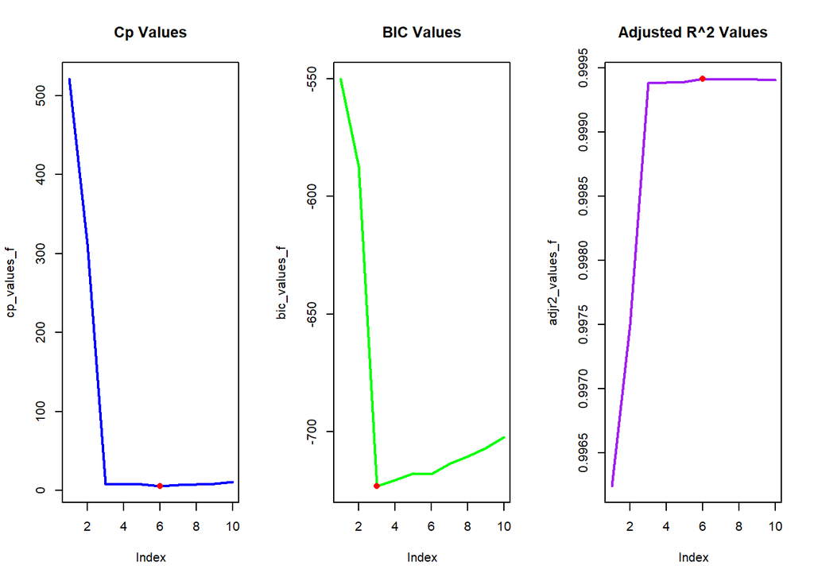

```r
par(mfrow = c(1, 3))
plot(cp_values_f, main = "Cp Values", type = "l", col = "blue", lwd = 2)
points(min_cp_index_f, cp_values_f[min_cp_index_f], col = "red", pch = 16)

plot(bic_values_f, main = "BIC Values", type = "l", col = "green", lwd = 2)
points(min_bic_index_f, bic_values_f[min_bic_index_f], col = "red", pch = 16)

plot(adjr2_values_f, main = "Adjusted R^2 Values", type = "l", col = "purple", lwd = 2)
points(max_adjr2_index_f, adjr2_values_f[max_adjr2_index_f], col = "red", pch = 16)
```

- The forward stepwise selection is changed our best subset approach, looking minimum Cp value and maximum AdjR2 values we can create a model with six variable. We add one more variable with this method.

```r
bic_values_f
```

```
 [1] -550.1084 -587.3166 -723.1050 -720.4382 -717.5197 -717.9749 -713.5628
 [8] -710.4239 -706.8920 -702.2883
```

- The BIC value is not lowest on the six variable however with looking cp and adjr2 we can choose six variable model as best subset with method forward.

```r
coef(reg_forward, id = 6)
```

```
                            (Intercept) poly(x, 10, raw = TRUE, simple = TRUE)1
                           24.270700704                             3.592399490
poly(x, 10, raw = TRUE, simple = TRUE)2 poly(x, 10, raw = TRUE, simple = TRUE)3
                            0.198985488                             4.738086210
poly(x, 10, raw = TRUE, simple = TRUE)4 poly(x, 10, raw = TRUE, simple = TRUE)6
                            0.325642644                            -0.033133319
poly(x, 10, raw = TRUE, simple = TRUE)7
                            0.004795928
```

```r
reg_backward <- regsubsets(y~poly(x,10,raw = TRUE, simple = TRUE), nvmax = 10, data = df, method='backward')
summary(reg_backward)
```

```
Subset selection object
Call: regsubsets.formula(y ~ poly(x, 10, raw = TRUE, simple = TRUE),
    nvmax = 10, data = df, method = "backward")
10 Variables  (and intercept)
                                         Forced in Forced out
poly(x, 10, raw = TRUE, simple = TRUE)1      FALSE      FALSE
poly(x, 10, raw = TRUE, simple = TRUE)2      FALSE      FALSE
poly(x, 10, raw = TRUE, simple = TRUE)3      FALSE      FALSE
poly(x, 10, raw = TRUE, simple = TRUE)4      FALSE      FALSE
poly(x, 10, raw = TRUE, simple = TRUE)5      FALSE      FALSE
poly(x, 10, raw = TRUE, simple = TRUE)6      FALSE      FALSE
poly(x, 10, raw = TRUE, simple = TRUE)7      FALSE      FALSE
poly(x, 10, raw = TRUE, simple = TRUE)8      FALSE      FALSE
poly(x, 10, raw = TRUE, simple = TRUE)9      FALSE      FALSE
poly(x, 10, raw = TRUE, simple = TRUE)10     FALSE      FALSE
```

[output cut: 112 more lines]

```r
cp_values_b <- summary(reg_backward)$cp
bic_values_b <- summary(reg_backward)$bic
adjr2_values_b <- summary(reg_backward)$adjr2
```

```r
min_cp_index_b <- which.min(cp_values_b)
min_bic_index_b <- which.min(bic_values_b)
max_adjr2_index_b <- which.max(adjr2_values_b)
```

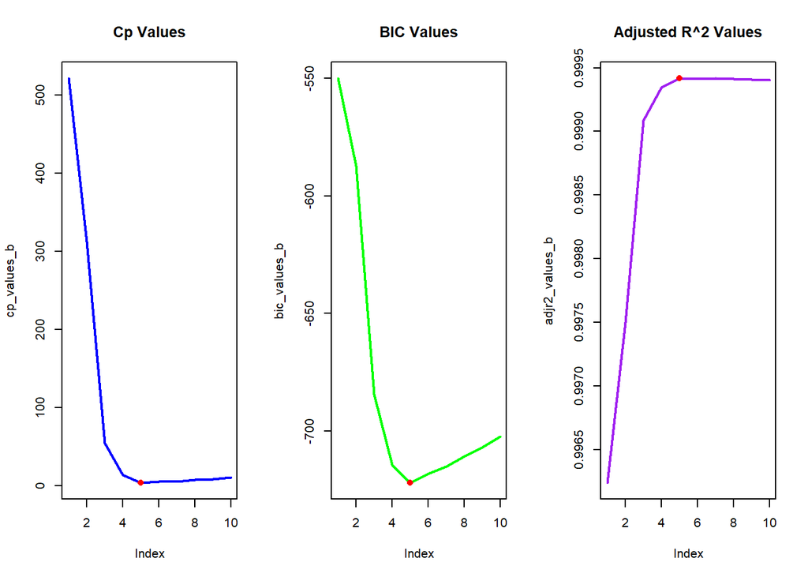

```r
par(mfrow = c(1, 3))
plot(cp_values_b, main = "Cp Values", type = "l", col = "blue", lwd = 2)
points(min_cp_index_b, cp_values_b[min_cp_index_b], col = "red", pch = 16)

plot(bic_values_b, main = "BIC Values", type = "l", col = "green", lwd = 2)
points(min_bic_index_b, bic_values_b[min_bic_index_b], col = "red", pch = 16)

plot(adjr2_values_b, main = "Adjusted R^2 Values", type = "l", col = "purple", lwd = 2)
points(max_adjr2_index_b, adjr2_values_b[max_adjr2_index_b], col = "red", pch = 16)
```

- The best subset suggested by backward selection is more consistent, because looking minimum Cp value, minimum BIC value and maximum AdjR2 values we can create a model with five variable. All of the values are on the same side right now. :)

```r
coef(reg_backward, id = 5)
```

```
                            (Intercept) poly(x, 10, raw = TRUE, simple = TRUE)1
                           24.335496477                             3.668163236
poly(x, 10, raw = TRUE, simple = TRUE)3 poly(x, 10, raw = TRUE, simple = TRUE)4
                            4.696493135                             0.398792218
poly(x, 10, raw = TRUE, simple = TRUE)6 poly(x, 10, raw = TRUE, simple = TRUE)7
                           -0.040213431                             0.005753268
```

### 8.e

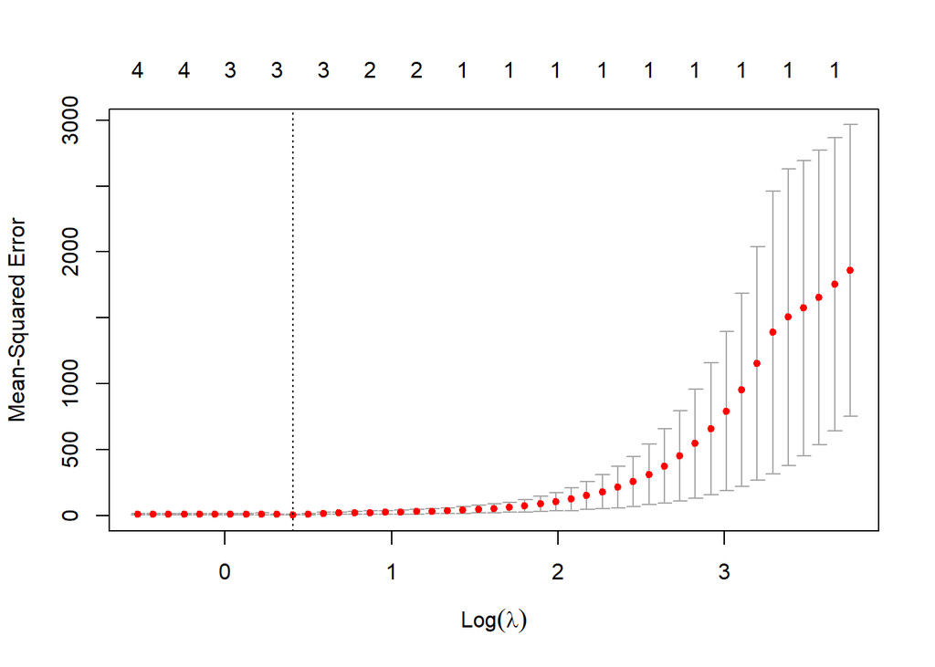

```r
x_ten <- poly(x,10,raw = TRUE, simple = TRUE)
lasso_model <- cv.glmnet(y=y,x=x_ten, alpha = 1)
plot(lasso_model)
```

```r
optimal_lambda <- lasso_model$lambda.min
coefficients_lasso <- coef(lasso_model, s = optimal_lambda)
coefficients_lasso
```

```
11 x 1 sparse Matrix of class "dgCMatrix"
                   s1
(Intercept) 25.170494
1            1.518825
2            0.259736
3            5.063645
4            .
5            .
6            .
7            .
8            .
9            .
10           .
```

### 8.f

```r
y1 <- 3 + 2*x^7 + ep
```

```r
df1 <- data.frame(x,y1)
reg1 <- regsubsets(y1~poly(x,10,raw = TRUE, simple = TRUE), nvmax = 10, data = df1)
summary(reg1)
```

```
Subset selection object
Call: regsubsets.formula(y1 ~ poly(x, 10, raw = TRUE, simple = TRUE),
    nvmax = 10, data = df1)
10 Variables  (and intercept)
                                         Forced in Forced out
poly(x, 10, raw = TRUE, simple = TRUE)1      FALSE      FALSE
poly(x, 10, raw = TRUE, simple = TRUE)2      FALSE      FALSE
poly(x, 10, raw = TRUE, simple = TRUE)3      FALSE      FALSE
poly(x, 10, raw = TRUE, simple = TRUE)4      FALSE      FALSE
poly(x, 10, raw = TRUE, simple = TRUE)5      FALSE      FALSE
poly(x, 10, raw = TRUE, simple = TRUE)6      FALSE      FALSE
poly(x, 10, raw = TRUE, simple = TRUE)7      FALSE      FALSE
poly(x, 10, raw = TRUE, simple = TRUE)8      FALSE      FALSE
poly(x, 10, raw = TRUE, simple = TRUE)9      FALSE      FALSE
poly(x, 10, raw = TRUE, simple = TRUE)10     FALSE      FALSE
```

[output cut: 112 more lines]

```r
cp_values1 <- summary(reg1)$cp
bic_values1 <- summary(reg1)$bic
adjr2_values1 <- summary(reg1)$adjr2
```

```r
min_cp_index1 <- which.min(cp_values1)
min_bic_index1 <- which.min(bic_values1)
max_adjr2_index1 <- which.max(adjr2_values1)
```

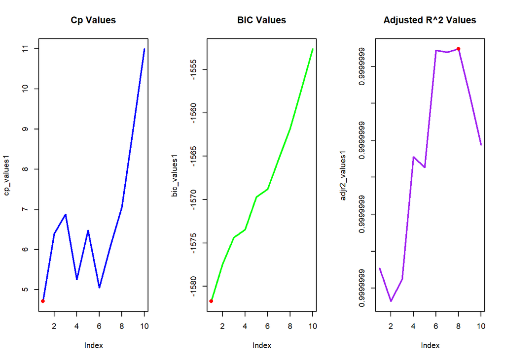

```r
par(mfrow = c(1, 3))
plot(cp_values1, main = "Cp Values", type = "l", col = "blue", lwd = 2)
points(min_cp_index1, cp_values1[min_cp_index1], col = "red", pch = 16)

plot(bic_values1, main = "BIC Values", type = "l", col = "green", lwd = 2)
points(min_bic_index1, bic_values1[min_bic_index1], col = "red", pch = 16)

plot(adjr2_values1, main = "Adjusted R^2 Values", type = "l", col = "purple", lwd = 2)
points(max_adjr2_index1, adjr2_values1[max_adjr2_index1], col = "red", pch = 16)
```

- With looking minimum Cp value and minimum BIC values we can create a model with one variable.
- The matrix from summary of regsubsets showing include X7 for single variable model. (same as our generated function)

```r
coef(reg1, id = 1)
```

```
                            (Intercept) poly(x, 10, raw = TRUE, simple = TRUE)7
                               3.084077                                1.999952
```

- The coefficient as we would expect.
- Intercept is close to 3.08 which is very close the 3.
- The model has contained X^7 and the value is so close to our coefficient which is 2.

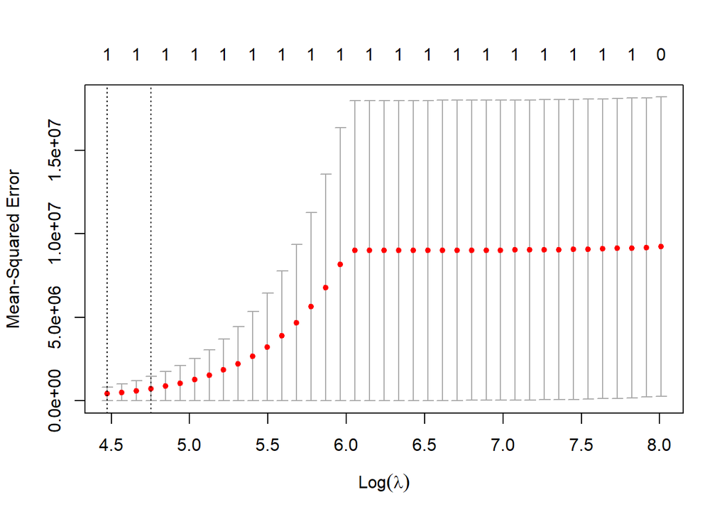

```r
x_ten1 <- poly(x,10,raw = TRUE, simple = TRUE)
lasso_model1 <- cv.glmnet(y=y1,x=x_ten1, alpha = 1)
plot(lasso_model1)
```

```r
optimal_lambda1 <- lasso_model1$lambda.min
coefficients_lasso1 <- coef(lasso_model1, s = optimal_lambda1)
coefficients_lasso1
```

```
11 x 1 sparse Matrix of class "dgCMatrix"
                   s1
(Intercept) 11.595322
1            .
2            .
3            .
4            .
5            .
6            .
7            1.941653
8            .
9            .
10           .
```

- The coefficent as expected but the intercept point is not.
- Intercept is much higher than 3.
- The model has contained X^7 and the value is so close to our coefficient which is 2.

## 9

### 9.a

```r
set.seed(1907)
train_indices <- sample(1:nrow(College), nrow(College) * 0.75)
train_set <- College[train_indices, ]
test_set <- College[-train_indices, ]
```

### 9.b

- The lm function used to perform least squares linear regression so I can use that.

```r
lm <- lm(Apps~., train_set)
summary(lm)
```

```
Call:
lm(formula = Apps ~ ., data = train_set)

Residuals:
    Min      1Q  Median      3Q     Max
-2212.8  -400.0   -47.6   315.3  6391.3

Coefficients:
              Estimate Std. Error t value Pr(>|t|)
(Intercept) -246.22396  414.71592  -0.594 0.552939
PrivateYes  -516.87663  137.20046  -3.767 0.000182 ***
Accept         1.35598    0.05439  24.931  < 2e-16 ***
Enroll        -0.47472    0.18998  -2.499 0.012744 *
Top10perc     51.24397    5.56507   9.208  < 2e-16 ***
Top25perc    -15.34539    4.39223  -3.494 0.000514 ***
F.Undergrad    0.08631    0.03138   2.750 0.006147 **
P.Undergrad   -0.01310    0.03913  -0.335 0.737865
Outstate      -0.05035    0.01908  -2.639 0.008541 **
Room.Board     0.17733    0.04670   3.798 0.000162 ***
Books          0.26725    0.24436   1.094 0.274554
Personal      -0.02751    0.06056  -0.454 0.649832
PhD           -6.83589    4.34011  -1.575 0.115805
Terminal      -4.71592    4.81925  -0.979 0.328218
S.F.Ratio      4.09314   13.00889   0.315 0.753150
perc.alumni   -7.66863    3.86970  -1.982 0.047996 *
Expend         0.04504    0.01122   4.015 6.76e-05 ***
Grad.Rate      8.11889    2.90293   2.797 0.005337 **
---
Signif. codes:  0 '***' 0.001 '**' 0.01 '*' 0.05 '.' 0.1 ' ' 1

Residual standard error: 879.7 on 564 degrees of freedom
Multiple R-squared:  0.9312,    Adjusted R-squared:  0.9291
F-statistic: 448.7 on 17 and 564 DF,  p-value: < 2.2e-16
```

```r
pred <- predict(lm, newdata = test_set)
test_error <- mean((pred - test_set$Apps)^2)
test_error
```

```
[1] 2276582
```

### 9.c

```r
x_train <- model.matrix(Apps ~ ., data = train_set)
y_train <- train_set$Apps
x_test <- model.matrix(Apps ~ ., data = test_set)
```

```r
ridge_model <- cv.glmnet(x_train,y_train, alpha = 0)
ridge_model
```

```
Call:  cv.glmnet(x = x_train, y = y_train, alpha = 0)

Measure: Mean-Squared Error

    Lambda Index Measure     SE Nonzero
min  310.7   100  982426 159194      17
1se  787.8    90 1137846 186390      17
```

```r
lambda <- ridge_model$lambda.min
lambda
```

```
[1] 310.7218
```

```r
ridge <- glmnet(x_train, y_train, alpha = 0, lambda = lambda)
ridge_pred <- predict(ridge, s = lambda, newx = x_test)
ridge_mse <- mean((ridge_pred - test_set$Apps)^2)
ridge_mse
```

```
[1] 3908528
```

- Best value of lambda is 310.7218 and the test MSE is higher than for least squares.

### 9.d

- We chose alpha equals 1 to create lasso regression

```r
lasso_model <- cv.glmnet(x_train, y_train, alpha = 1)
```

```r
lasso_lambda <- lasso_model$lambda.min
lasso_lambda
```

```
[1] 11.69848
```

```r
lasso <- glmnet(x_train, y_train, alpha = 1, lambda = lasso_lambda)
lasso_pred <- predict(lasso, s=lasso_lambda, newx = x_test)
lasso_mse <- mean((lasso_pred - test_set$Apps)^2)
lasso_mse
```

```
[1] 2415150
```

- Best value of lambda is 11.69848 and the test MSE is higher than for least squares lower than ridge.

```r
nonzero_lasso <- sum(coef(lasso, s = lasso_lambda) != 0)
nonzero_lasso
```

```
[1] 14
```

```r
coef(lasso, s = lasso_lambda)
```

```
19 x 1 sparse Matrix of class "dgCMatrix"
                       s1
(Intercept) -445.22247790
(Intercept)    .
PrivateYes  -492.01848866
Accept         1.27341132
Enroll         .
Top10perc     42.44477100
Top25perc     -8.77085488
F.Undergrad    0.02983705
P.Undergrad    .
Outstate      -0.03371674
Room.Board     0.16393039
Books          0.18679028
Personal       .
PhD           -5.80533463
Terminal      -3.95362692
S.F.Ratio      .
perc.alumni   -8.34537868
Expend         0.04154606
Grad.Rate      6.74454870
```

- The total number of the non-zero coefficients is 14 out of 19.